# Download the Data

```python
from google.colab import drive
drive.mount('/content/drive')
```

```
Go to this URL in a browser: https://accounts.google.com/o/oauth2/auth?client_id=947318989803-6bn6qk8qdgf4n4g3pfee6491hc0brc4i.apps.googleusercontent.com&redirect_uri=urn%3aietf%3awg%3aoauth%3a2.0%3aoob&response_type=code&scope=email%20https%3a%2f%2fwww.googleapis.com%2fauth%2fdocs.test%20https%3a%2…

Enter your authorization code:
··········
```

# Importations

```python
import pandas as pd
import numpy as np
import matplotlib.pyplot as plt
import seaborn as sns  #advanced visualization library
import warnings
warnings.filterwarnings('ignore')
```

# Fast EDA

```python
import pandas as pd
data = pd.read_csv('/content/drive/My Drive/Chicago_Traffic_Tracker_-_Historical_Congestion_Estimates_by_Region_-_2018-Current(1).csv')
```

```python
data.head()
```

|  | TIME | REGION_ID | SPEED | REGION | BUS_COUNT | NUM_READS | HOUR | DAY_OF_WEEK | MONTH | DESCRIPTION | RECORD_ID | WEST | EAST | SOUTH | NORTH | NW_LOCATION | SE_LOCATION |
| --- | --- | --- | --- | --- | --- | --- | --- | --- | --- | --- | --- | --- | --- | --- | --- | --- | --- |
| 0 | 04/29/2018 09:40:16 PM | 15 | 27.89 | Bridgeport-McKinley-Lower West | 19 | 312 | 21 | 1 | 4 | Pershing to Roosevel. Western to Stewart | 15-201804300240 | -87.685372 | -87.636322 | 41.822792 | 41.866129 | POINT (-87.685372 41.866129) | POINT (-87.636322 41.822792) |
| 1 | 04/29/2018 09:40:16 PM | 18 | 27.89 | South West Side | 25 | 492 | 21 | 1 | 4 | 71st to Pershing. Cicero to Western | 18-201804300240 | -87.747456 | -87.683730 | 41.764066 | 41.822792 | POINT (-87.747456 41.822792) | POINT (-87.68373 41.764066) |
| 2 | 04/29/2018 09:40:16 PM | 21 | 25.91 | Hyde Park-Kenwood-Woodlawn | 23 | 399 | 21 | 1 | 4 | 71st to Pershing. Cottage Grove to Lake Shore | 21-201804300240 | -87.606334 | -87.566260 | 41.764066 | 41.822792 | POINT (-87.606334 41.822792) | POINT (-87.56626 41.764066) |
| 3 | 04/29/2018 09:40:16 PM | 22 | 29.59 | Ashburn | 17 | 254 | 21 | 1 | 4 | 91st to 71st. Cicero to Damen | 22-201804300240 | -87.747456 | -87.672980 | 41.728472 | 41.764066 | POINT (-87.747456 41.764066) | POINT (-87.67298 41.728472) |
| 4 | 04/29/2018 09:40:16 PM | 23 | 23.86 | Auburn Gresham-Chatham | 41 | 585 | 21 | 1 | 4 | 91st to 71st. Damen to Cottage Grove | 23-201804300240 | -87.672980 | -87.606334 | 41.728472 | 41.764066 | POINT (-87.67298 41.764066) | POINT (-87.606334 41.728472) |

### Data description

- TIME : Timestamp of the record
- RGION_ID : Unique arbitrary number to represent each region
- SPEED : Estimated congestion level. Although expressed in miles per hour, this value is more a reflection of the congestion level in the region than it is indicative of the average raw speed vehicles are travelling within the region.
- REGION : Name of the region.
- BUS_COUNT : The number of buses used to estimate traffic.
- NUM_READS : Number of GPS probes received(or used) for estimating the speed for that segment.
- WEST: Approximate longitude of the west edge of the region.
- EAST: Approximate longitude of the east edge of the region.
- SOUTH : Approximate latitude of the south edge of the region.
- NORTH : Approximate latitude of the north edge of the region.
- NW_LOACATION : The location corresponding to the intersection of NORTH and WEST in a format that allows for creation of maps and other geographic operations on this data portal.
- SE_LOCATION : The location corresponding to the intersection of SOUTH and EAST in a format that allows for creation of maps and other geographic operations on this data portal.

### Feature engineering

```python
data["TIME"]=pd.to_datetime(data["TIME"], format="%m/%d/%Y %I:%M:%S %p")
```

```python
data["dayofweek"]=data["TIME"].dt.dayofweek
```

```python
data['DAY'] = data['TIME'].dt.day
data['MONTH'] = data['TIME'].dt.month
data['YEAR'] = data['TIME'].dt.year
```

```python
list_REGION = []
for i in range(29) :
    reg = data[(data['REGION_ID']==i+1)].REGION.unique()[0]
    list_REGION.append(reg)
```

```python
data = data.groupby(['REGION','REGION_ID','MONTH','DAY','YEAR','HOUR','NORTH','WEST','EAST', 'SOUTH','DAY_OF_WEEK'])[['SPEED','BUS_COUNT','NUM_READS']].agg('mean').reset_index()
```

```python
data['MINUTE'] = '00'
data['Time'] = pd.to_datetime(data[['YEAR','MONTH','DAY','HOUR','MINUTE']].astype(str).agg('-'.join,axis=1),format='%Y-%m-%d-%H-%M')
```

```python
data['CENTER_LAT']=data['NORTH']*0.5+0.5*data['SOUTH']
data['CENTER_LON']=data['EAST']*0.5+0.5*data['WEST']
data['Time'] = data.Time.dt.strftime("%a, %d %b, %Y at %l:%M %p")
```

## Graphics

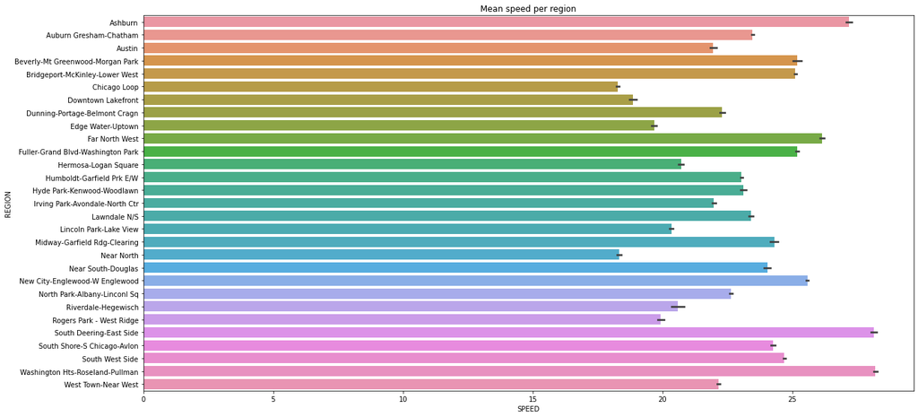

```python
plt.figure(figsize=(20,10))
plt.title("Mean speed per region")
sns.barplot(data.SPEED,data.REGION)
```

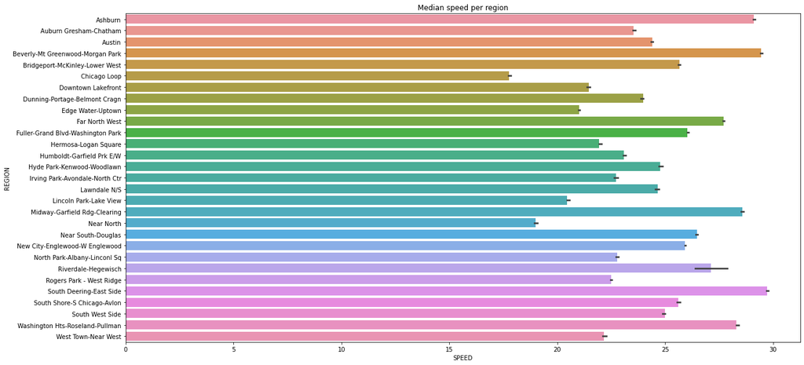

```python
from numpy import median
plt.figure(figsize=(20,10))
plt.title("Median speed per region")
sns.barplot(data.SPEED,data.REGION,estimator=median)
```

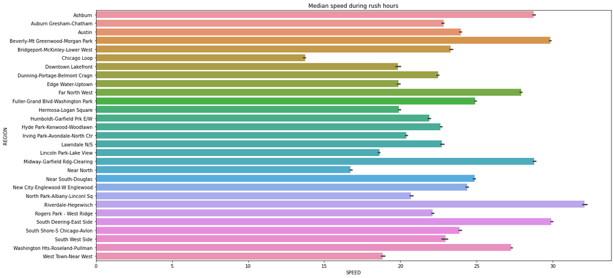

```python
data2=data[data["HOUR"].isin([8,9,15,16,17])]
plt.figure(figsize=(20,10))
plt.title("Median speed during rush hours")
sns.barplot(data2.SPEED,data2.REGION,estimator=median)
```

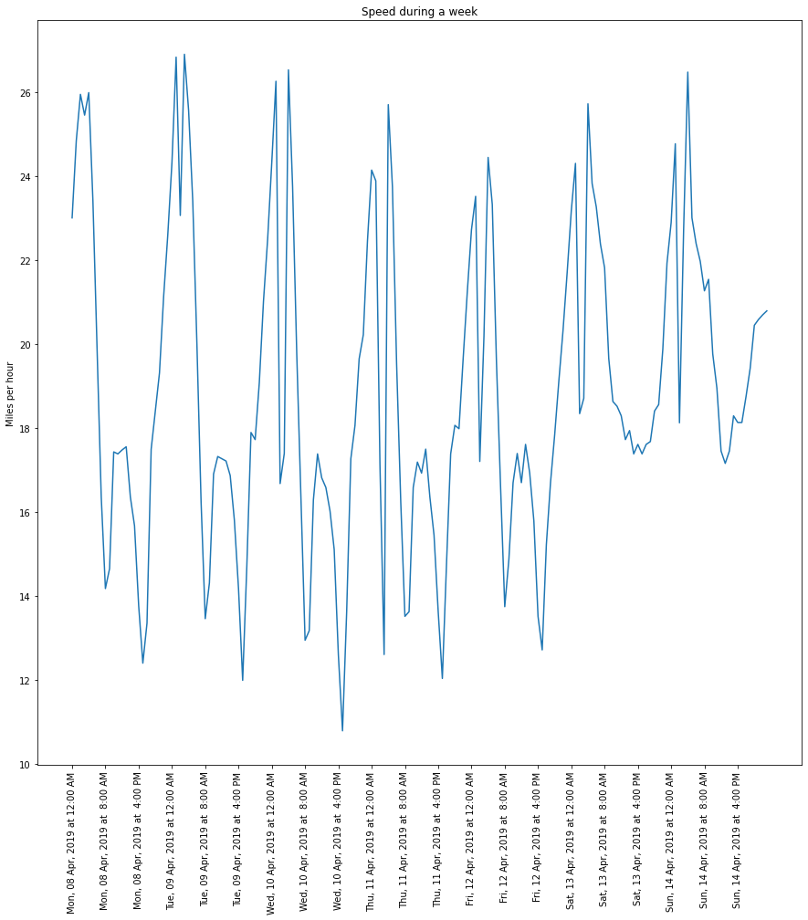

```python
from datetime import datetime
loop=data[data["REGION"].isin(["Chicago Loop"])]
loop=loop.drop_duplicates("Time",keep='first')
fig,ax=plt.subplots(1,1,figsize=(15,15))
sub_set = loop[(loop['YEAR']==2019) & (loop['MONTH'] == 4) & (8 <= loop['DAY']) & (loop['DAY'] <= 14)].copy()
timelist=sub_set["Time"]
plt.plot(sub_set.Time,sub_set.SPEED)
plt.title("Speed during a week")
plt.ylabel("Miles per hour")
ax.set_xticks(timelist[::8])
plt.xticks(rotation=90)
```